# Exercise ‘Manner’ Predictor

Andy Pritchard

21 May 2016

## Synopsis

The purpose of this assignment is to look at producing a machine learning model which can resonably predict the manner in which a set of test subjects peform a suite of exercises.

The model will use data from accelerometers on the belt, forearm, arm, and dumbell of the test subjects worn during exercise. This data will be used to predict the specification class as defined below:

Specifically (from http://groupware.les.inf.puc-rio.br/har#weight_lifting_exercises) “Six young health participants were asked to perform one set of 10 repetitions of the Unilateral Dumbbell Biceps Curl in five different fashions: exactly according to the specification (Class A), throwing the elbows to the front (Class B), lifting the dumbbell only halfway (Class C), lowering the dumbbell only halfway (Class D) and throwing the hips to the front (Class E).”

The data for this project is kindly provided by: http://groupware.les.inf.puc-rio.br/har in conjunction with the Coursera Data Science Specialization

## Exploratory Data Analysis

I first explored the data to see if any of the columns have no data and could be filtered out as predictors

```
## pml_training_NA
## FALSE
##   160
```

```
## pml_20recordcsv_NA
## FALSE  TRUE
##    60   100
```

It is to be noted that based on the above that the testing data does have empty columns whereas the training set does not. To avoid overfitting the model this fact will be ignored; however it may skew the results in later modelling.

The model is to use data from accelerometers on the belt, forearm, arm, and dumbell, so I will extract just those columns (predictors).

Now I have the required columns I’m going to see how much data is available in those columns

```
##                      NA.percentage
## var_total_accel_belt          97.9
## var_accel_arm                 97.9
## var_accel_dumbbell            97.9
## var_accel_forearm             97.9
## total_accel_belt               0.0
## accel_belt_x                   0.0
## accel_belt_y                   0.0
## accel_belt_z                   0.0
## total_accel_arm                0.0
## accel_arm_x                    0.0
## accel_arm_y                    0.0
## accel_arm_z                    0.0
## total_accel_dumbbell           0.0
## accel_dumbbell_x               0.0
## accel_dumbbell_y               0.0
## accel_dumbbell_z               0.0
## total_accel_forearm            0.0
## accel_forearm_x                0.0
## accel_forearm_y                0.0
## accel_forearm_z                0.0
## classe                         0.0
```

As you can see var_total_accel_belt, var_accel_arm, var_accel_dumbbell and var_accel_forearm all have 97.9% of missing data (NA). The author has decided to remove these columns (predictors) from the subsequent models

Now I have the final set of predictors I’m going to look to see if there are any outliers in the data which could skew the model

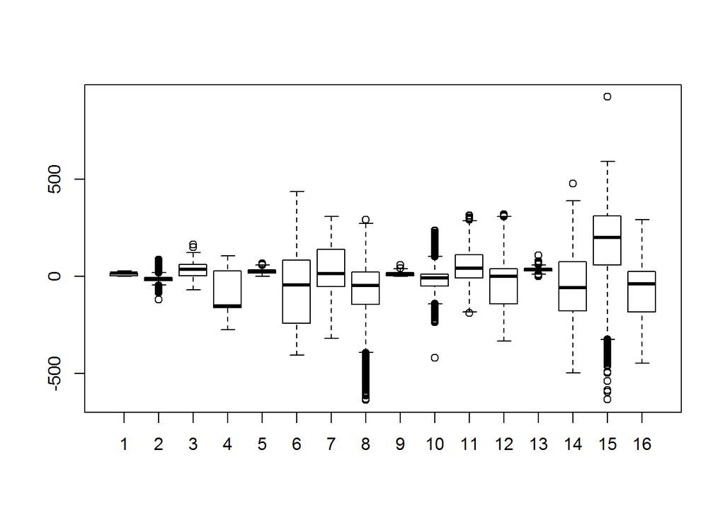

```
##  [1] "total_accel_belt"     "accel_belt_x"         "accel_belt_y"
##  [4] "accel_belt_z"         "total_accel_arm"      "accel_arm_x"
##  [7] "accel_arm_y"          "accel_arm_z"          "total_accel_dumbbell"
## [10] "accel_dumbbell_x"     "accel_dumbbell_y"     "accel_dumbbell_z"
## [13] "total_accel_forearm"  "accel_forearm_x"      "accel_forearm_y"
## [16] "accel_forearm_z"
```

As you can see accel_forearm_x, accel_forearm_y and accel_dumbbell_x have clear outliers and these will be removed by setting their values to the mean of of their respective columns, updated boxplot below:

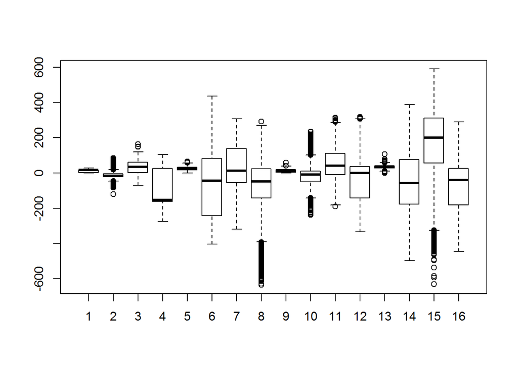

## Model Creation & Evaluation

### Create Cross Validation

The provided training data set will be split 60% for training and 40% for testing (model evaluation)

### Predictor Analysis

Now that I have a training data set I will perform some analysis to understand the individual importance of the predictors I have selected:

```
## rf variable importance
##
##                      Overall
## accel_dumbbell_y     100.000
## accel_belt_z          95.518
## accel_dumbbell_z      83.485
## accel_forearm_x       64.652
## accel_dumbbell_x      62.457
## accel_arm_x           59.811
## accel_forearm_z       41.088
## accel_arm_y           34.037
## accel_arm_z           28.687
## total_accel_dumbbell  25.813
## accel_forearm_y       21.730
## total_accel_belt      16.930
## accel_belt_x          13.796
## accel_belt_y           7.584
## total_accel_forearm    3.410
## total_accel_arm        0.000
```

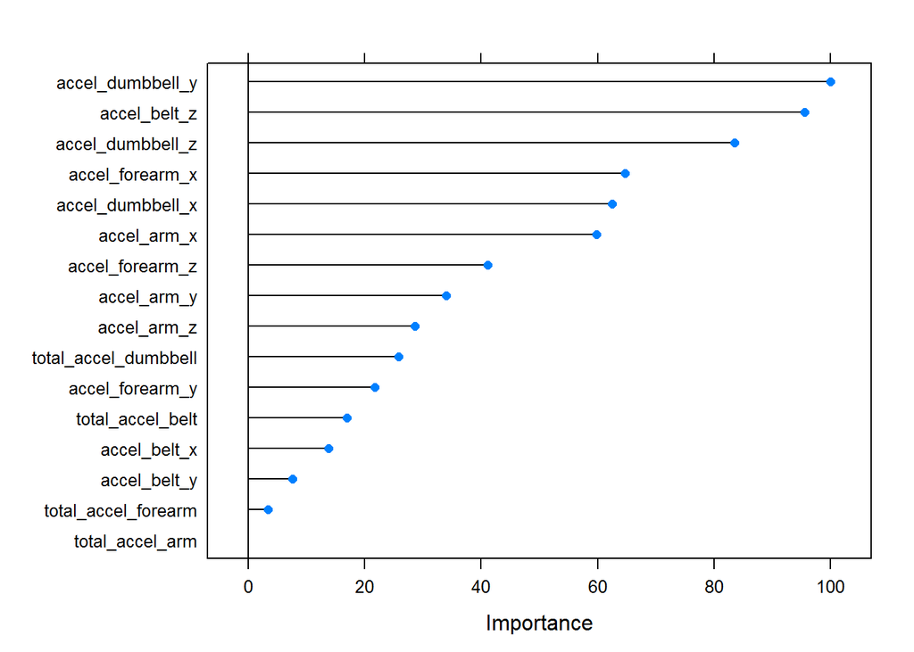

As you can see the total_accel_arm column has shown not to be significant in relation to prediction and could be removed.

### Model Selection

[output not shown]

## Results

As you see the Random Forest algorithm is clearly best fitted to this particular problem domain and will be used on the (provided) 20 record test data set. My Random Forest model predicts the following for the 20 records:

```
##  [1] B A B A A E D B A A B C B A E E A B B B
## Levels: A B C D E
```

## Appendix - R Code

```r
library(knitr)
library(caret)
library(randomForest)

opts_chunk$set(echo = TRUE,warning=FALSE,message=FALSE)

set.seed(1234)
```

### Loading and preprocessing the data

```r
if (!file.exists("datadir"))
{
  dir.create("datadir")
}

download.file("https://d396qusza40orc.cloudfront.net/predmachlearn/pml-training.csv",
              "./datadir/pml-training.csv",mode="wb")

download.file("https://d396qusza40orc.cloudfront.net/predmachlearn/pml-testing.csv",
              "./datadir/pml-testing.csv",mode="wb")

#read in test and training sets
pml_training <- read.csv("./datadir/pml-training.csv", sep = ",", stringsAsFactors = FALSE, header= TRUE)
pml_20recordcsv <- read.csv("./datadir/pml-testing.csv", sep = ",", stringsAsFactors = FALSE, header= TRUE)
```